# Chapter 6

For fun, let’s look at the weights from the 40-day mark until the end of the study by using boxplots. I don’t think it makes sense here to do it similarly as to the BPRS data in MABS, that we would exclude only the baseline measurements. The effects of the diet are most likely only showing later in the course of the study, not directly after starting the diet. Also, the weights of the rats are not the same at the baseline, so without knowing the purpose of the study in more detail, it is impossible to tell if the groups are even comparable at all.

```r
library(tidyverse)
# Summary data with mean weight from 40 days onwards
RATSSbp <- RATSL %>%
  filter(Time >= 40) %>%
  group_by(Group, ID) %>%
  summarise(meanWeight = mean(Weight)) %>%
  ungroup()
# Glimpse the data
glimpse(RATSSbp)
```

```
## Rows: 16
## Columns: 3
## $ Group      <fct> 1, 1, 1, 1, 1, 1, 1, 1, 2, 2, 2, 2, 3, 3, 3, 3
## $ ID         <fct> 1, 2, 3, 4, 5, 6, 7, 8, 9, 10, 11, 12, 13, 14, 15, 16
## $ meanWeight <dbl> 269.4, 243.4, 267.0, 272.8, 276.2, 280.0, 278.8, 271.4, 458…
```

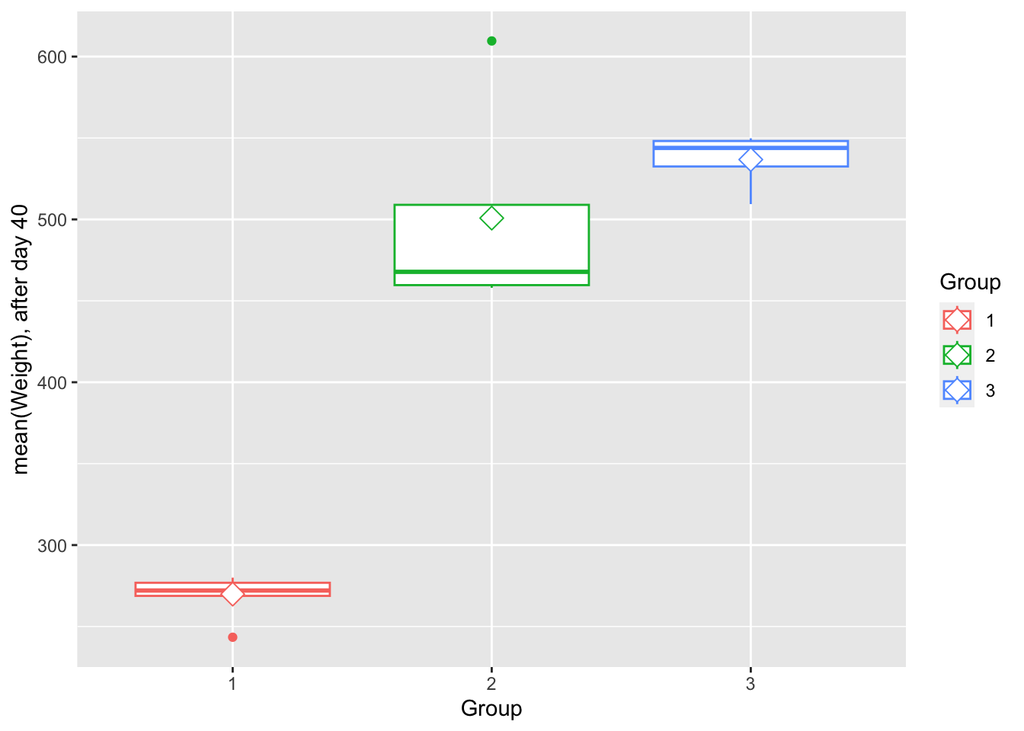

```r
# Boxplot comparing the diet groups
library(ggplot2)
ggplot(RATSSbp, aes(x = Group, y = meanWeight, col = Group)) +
  geom_boxplot() +
  stat_summary(fun = "mean", geom = "point", shape=23, size=4, fill = "white") +
  scale_y_continuous(name = "mean(Weight), after day 40")
```

There seems to be one outlier value in group 1 and also in group 2. Let’s remove the outliers.

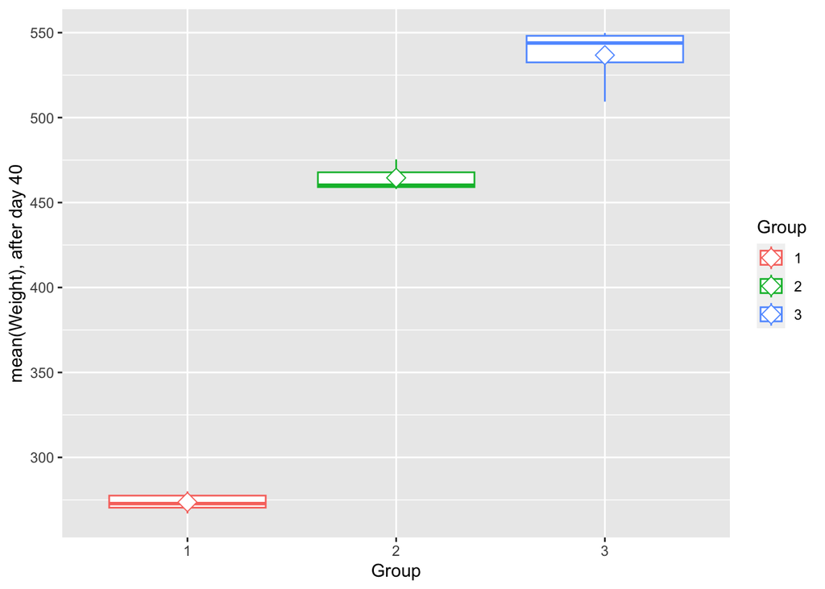

```r
# Filter out the outlier values (smallest and largest weight value of the dataset)
RATSSbp2 <- RATSSbp %>%
  filter(250 < meanWeight & meanWeight < 560)

# Draw new boxplots
library(ggplot2)
ggplot(RATSSbp2, aes(x = Group, y = meanWeight, col = Group)) +
  geom_boxplot() +
  stat_summary(fun = "mean", geom = "point", shape=23, size=4, fill = "white") +
  scale_y_continuous(name = "mean(Weight), after day 40")
```

Now the outliers have been removed and intragroup variation has decreased at least in group 2. Let’s move on to perform anova.

```r
library(dplyr)
library(tidyr)
# Add the first 39 days mean from the original data as a new variable to the summary data
first39 <- RATSL %>%
filter(Time < 40) %>%
  group_by(Group, ID) %>%
  summarise(meanWeight = mean(Weight)) %>%
  ungroup()
glimpse(first39)
```

```
## Rows: 16
## Columns: 3
## $ Group      <fct> 1, 1, 1, 1, 1, 1, 1, 1, 2, 2, 2, 2, 3, 3, 3, 3
## $ ID         <fct> 1, 2, 3, 4, 5, 6, 7, 8, 9, 10, 11, 12, 13, 14, 15, 16
## $ meanWeight <dbl> 254.1667, 232.8333, 254.5000, 261.3333, 263.8333, 270.3333,…
```

```r
first39 <- first39[-c(2,12),]

RATSS_analysis <- RATSSbp2 %>%
  mutate(first39Days = first39$meanWeight)

glimpse(RATSS_analysis)
```

```
## Rows: 14
## Columns: 4
## $ Group       <fct> 1, 1, 1, 1, 1, 1, 1, 2, 2, 2, 3, 3, 3, 3
## $ ID          <fct> 1, 3, 4, 5, 6, 7, 8, 9, 10, 11, 13, 14, 15, 16
## $ meanWeight  <dbl> 269.4, 267.0, 272.8, 276.2, 280.0, 278.8, 271.4, 458.0, 47…
## $ first39Days <dbl> 254.1667, 254.5000, 261.3333, 263.8333, 270.3333, 271.1667…
```

```r
# Fit the linear model with the mean as the response
fit <- lm(meanWeight ~ first39Days + Group, data = RATSS_analysis)

# Compute the analysis of variance table for the fitted model with anova()
anova(fit)
```

```
## Analysis of Variance Table
##
## Response: meanWeight
##             Df Sum Sq Mean Sq   F value    Pr(>F)
## first39Days  1 197648  197648 3917.3952 2.637e-14 ***
## Group        2    772     386    7.6552  0.009627 **
## Residuals   10    505      50
## ---
## Signif. codes:  0 '***' 0.001 '**' 0.01 '*' 0.05 '.' 0.1 ' ' 1
```

Both the diet group and weight during the first 39 days are statistically significantly associated to the response variable (mean weight at the end stage of the study).

First, we’ll read in the data.

```r
# Read in the data in long format
getwd()
```

```
## [1] "/Users/hchaltia/Open data science course/IODS-project/data"
```

```r
BPRSL <- read.csv("BPRSL.csv")

# Explore the dimensions
dim(BPRSL)
```

```
## [1] 360   6
```

```r
str(BPRSL)
```

```
## 'data.frame':    360 obs. of  6 variables:
##  $ X        : int  1 2 3 4 5 6 7 8 9 10 ...
##  $ treatment: int  1 1 1 1 1 1 1 1 1 1 ...
##  $ subject  : int  1 2 3 4 5 6 7 8 9 10 ...
##  $ weeks    : chr  "week0" "week0" "week0" "week0" ...
##  $ bprs     : int  42 58 54 55 72 48 71 30 41 57 ...
##  $ week     : int  0 0 0 0 0 0 0 0 0 0 ...
```